# Proyecto SRP162774 de recount 3

### Emmanuel Hernández Sánchez

Se decidió analizó los datos del proyecto “SRP162774” de recount 3, para lo cual primero se tienen que descargar los datos de los proyectos de humanos para después buscar el proyecto.

```r
#Se extraen los proyectos de humanos de recount 3 para encontrar el proyecto en específico.
library("recount3")
human_projects <- available_projects()
```

```
## 2021-02-28 15:16:50 caching file sra.recount_project.MD.gz.
```

```
## 2021-02-28 15:16:51 caching file gtex.recount_project.MD.gz.
```

```
## 2021-02-28 15:16:56 caching file tcga.recount_project.MD.gz.
```

```r
# Se  el proyecto "SRP162774" de recount 3.
rse_gene_SRP162774 <- create_rse(subset(
  human_projects,
  project == "SRP162774" & project_type == "data_sources"
))
```

```
## 2021-02-28 15:17:13 downloading and reading the metadata.
```

```
## 2021-02-28 15:17:15 caching file sra.sra.SRP162774.MD.gz.
```

```
## 2021-02-28 15:17:16 caching file sra.recount_project.SRP162774.MD.gz.
```

```
## 2021-02-28 15:17:17 caching file sra.recount_qc.SRP162774.MD.gz.
```

```
## 2021-02-28 15:17:19 caching file sra.recount_seq_qc.SRP162774.MD.gz.
```

```
## 2021-02-28 15:17:20 caching file sra.recount_pred.SRP162774.MD.gz.
```

```
## 2021-02-28 15:17:22 downloading and reading the feature information.
```

```
## 2021-02-28 15:17:23 caching file human.gene_sums.G026.gtf.gz.
```

```
## 2021-02-28 15:17:24 downloading and reading the counts: 911 samples across 63856 features.
```

```
## 2021-02-28 15:17:26 caching file sra.gene_sums.SRP162774.G026.gz.
```

```
## 2021-02-28 15:18:27 construcing the RangedSummarizedExperiment (rse) object.
```

```r
#Conversión de cuentas por nucleotido a cuentas por lectura.
assay(rse_gene_SRP162774, "counts") <- compute_read_counts(rse_gene_SRP162774)
# Se explora el objeto creado.
rse_gene_SRP162774
```

```
## class: RangedSummarizedExperiment
## dim: 63856 911
## metadata(8): time_created recount3_version ... annotation recount3_url
## assays(2): raw_counts counts
## rownames(63856): ENSG00000278704.1 ENSG00000277400.1 ...
##   ENSG00000182484.15_PAR_Y ENSG00000227159.8_PAR_Y
## rowData names(10): source type ... havana_gene tag
## colnames(911): SRR7911000 SRR7911001 ... SRR7910995 SRR7910996
## colData names(175): rail_id external_id ...
##   recount_pred.curated.cell_line BigWigURL
```

Como se puede observar del objeto de RangedSumarizedExperiment el proyecto tiene 63856 genes, 911 muestras y 10 renglones de datos.

```r
# Se observan los atributos de 10 muestras para verificar que
#el número de campos sea igual en todos los casos.
rse_gene_SRP162774$sra.sample_attributes[10:20]
```

```
##  [1] "cell type;;peripheral blood mononuclear cell|drug treatment;;ibuprofen sodium|gender;;male|library barcode;;AGCGATAG-GGCTCTGA|response group;;Full responder|source_name;;peripheral blood mononuclear cell|subject;;1022|timepoint;;baseline"
##  [2] "cell type;;peripheral blood mononuclear cell|drug treatment;;ibuprofen sodium|gender;;male|library barcode;;AGCGATAG-GGCTCTGA|response group;;Full responder|source_name;;peripheral blood mononuclear cell|subject;;1022|timepoint;;baseline"
##  [3] "cell type;;peripheral blood mononuclear cell|drug treatment;;ibuprofen sodium|gender;;male|library barcode;;AGCGATAG-GGCTCTGA|response group;;Full responder|source_name;;peripheral blood mononuclear cell|subject;;1022|timepoint;;baseline"
##  [4] "cell type;;peripheral blood mononuclear cell|drug treatment;;ibuprofen sodium|gender;;male|library barcode;;AGCGATAG-GGCTCTGA|response group;;Full responder|source_name;;peripheral blood mononuclear cell|subject;;1022|timepoint;;baseline"
##  [5] "cell type;;peripheral blood mononuclear cell|drug treatment;;ibuprofen sodium|gender;;male|library barcode;;AGCGATAG-GGCTCTGA|response group;;Full responder|source_name;;peripheral blood mononuclear cell|subject;;1022|timepoint;;baseline"
##  [6] "cell type;;peripheral blood mononuclear cell|drug treatment;;ibuprofen sodium|gender;;male|library barcode;;AGCGATAG-GGCTCTGA|response group;;Full responder|source_name;;peripheral blood mononuclear cell|subject;;1022|timepoint;;baseline"
##  [7] "cell type;;peripheral blood mononuclear cell|drug treatment;;ibuprofen sodium|gender;;male|library barcode;;ATTACTCG-AGGCGAAG|response group;;Full responder|source_name;;peripheral blood mononuclear cell|subject;;1022|timepoint;;post-surgery 1"
##  [8] "cell type;;peripheral blood mononuclear cell|drug treatment;;ibuprofen sodium|gender;;male|library barcode;;ATTACTCG-AGGCGAAG|response group;;Full responder|source_name;;peripheral blood mononuclear cell|subject;;1022|timepoint;;post-surgery 1"
##  [9] "cell type;;peripheral blood mononuclear cell|drug treatment;;ibuprofen sodium|gender;;male|library barcode;;ATTACTCG-AGGCGAAG|response group;;Full responder|source_name;;peripheral blood mononuclear cell|subject;;1022|timepoint;;post-surgery 1"
## [10] "cell type;;peripheral blood mononuclear cell|drug treatment;;ibuprofen sodium|gender;;male|library barcode;;ATTACTCG-AGGCGAAG|response group;;Full responder|source_name;;peripheral blood mononuclear cell|subject;;1022|timepoint;;post-surgery 1"
## [11] "cell type;;peripheral blood mononuclear cell|drug treatment;;ibuprofen sodium|gender;;male|library barcode;;ATTACTCG-AGGCGAAG|response group;;Full responder|source_name;;peripheral blood mononuclear cell|subject;;1022|timepoint;;post-surgery 1"
```

```r
#Al no observarse diferencia alguna se procede a visualizar
#la información que se puede obtener del proyecto
rse_gene_SRP162774 <- expand_sra_attributes(rse_gene_SRP162774)
colData(rse_gene_SRP162774)[
  ,
  grepl("^sra_attribute", colnames(colData(rse_gene_SRP162774)))
]
```

```
## DataFrame with 911 rows and 8 columns
##            sra_attribute.cell_type sra_attribute.drug_treatment
##                        <character>                  <character>
## SRR7911000  peripheral blood mon..             ibuprofen sodium
## SRR7911001  peripheral blood mon..             ibuprofen sodium
## SRR7911004  peripheral blood mon..             ibuprofen sodium
## SRR7911005  peripheral blood mon..             ibuprofen sodium
## SRR7911006  peripheral blood mon..             ibuprofen sodium
## ...                            ...                          ...
## SRR7910943  peripheral blood mon..                      Placebo
## SRR7910948  peripheral blood mon..                      Placebo
## SRR7910954  peripheral blood mon..                      Placebo
## SRR7910995  peripheral blood mon..             ibuprofen sodium
## SRR7910996  peripheral blood mon..             ibuprofen sodium
##            sra_attribute.gender sra_attribute.library_barcode
##                     <character>                   <character>
## SRR7911000               female             TCTCGCGC-GGCTCTGA
## SRR7911001               female             TCTCGCGC-GGCTCTGA
## SRR7911004                 male             AGCGATAG-GGCTCTGA
## SRR7911005                 male             AGCGATAG-GGCTCTGA
## SRR7911006                 male             AGCGATAG-GGCTCTGA
## ...                         ...                           ...
## SRR7910943               female             CTGAAGCT-GGCTCTGA
## SRR7910948               female             TAATGCGC-GGCTCTGA
## SRR7910954               female             TAATGCGC-GGCTCTGA
## SRR7910995               female             TCTCGCGC-GGCTCTGA
## SRR7910996               female             TCTCGCGC-GGCTCTGA
##            sra_attribute.response_group sra_attribute.source_name
##                             <character>               <character>
## SRR7911000            Partial responder    peripheral blood mon..
## SRR7911001            Partial responder    peripheral blood mon..
## SRR7911004               Full responder    peripheral blood mon..
## SRR7911005               Full responder    peripheral blood mon..
## SRR7911006               Full responder    peripheral blood mon..
## ...                                 ...                       ...
## SRR7910943                      Placebo    peripheral blood mon..
## SRR7910948                      Placebo    peripheral blood mon..
## SRR7910954                      Placebo    peripheral blood mon..
## SRR7910995            Partial responder    peripheral blood mon..
## SRR7910996            Partial responder    peripheral blood mon..
##            sra_attribute.subject sra_attribute.timepoint
##                      <character>             <character>
## SRR7911000                  1021          post-surgery 2
## SRR7911001                  1021          post-surgery 2
## SRR7911004                  1022                baseline
## SRR7911005                  1022                baseline
## SRR7911006                  1022                baseline
## ...                          ...                     ...
## SRR7910943                  1020          post-surgery 1
## SRR7910948                  1020          post-surgery 2
## SRR7910954                  1020          post-surgery 2
## SRR7910995                  1021          post-surgery 2
## SRR7910996                  1021          post-surgery 2
```

De este proyecto s puede observar que tiene 5 atributos de 8 que se pudieran elegir para un análisis estadístico (los campos de drug_treatment, gender, library_barcode, response_group y timepoint).

```r
#Se decidió utilizar 5 variables.
rse_gene_SRP162774$sra_attribute.drug_treatment <- factor(rse_gene_SRP162774$sra_attribute.drug_treatment)
rse_gene_SRP162774$sra_attribute.gender <- factor(rse_gene_SRP162774$sra_attribute.gender)
rse_gene_SRP162774$sra_attribute.timepoint <- factor(rse_gene_SRP162774$sra_attribute.timepoint)
rse_gene_SRP162774$sra_attribute.library_barcode <- factor(rse_gene_SRP162774$sra_attribute.library_barcode)
rse_gene_SRP162774$sra_attribute.response_group <- factor(rse_gene_SRP162774$sra_attribute.response_group)

summary(as.data.frame(colData(rse_gene_SRP162774)[
  ,
  grepl("^sra_attribute.[drug_treatment|gender|response_group|timepoint|library_barcode]", colnames(colData(rse_gene_SRP162774)))
]))
```

```
##  sra_attribute.cell_type   sra_attribute.drug_treatment sra_attribute.gender
##  Length:911              ibuprofen sodium:577           female:416
##  Class :character        Placebo         :334           male  :495
##  Mode  :character
##
##
##
##
##    sra_attribute.library_barcode    sra_attribute.response_group
##  AGCGATAG-ATAGAGGC: 14           Full responder   :286
##  AGCGATAG-CCTATCCT: 14           Partial responder:291
##  AGCGATAG-TAATCTTA: 14           Placebo          :334
##  ATTACTCG-AGGCGAAG: 14
##  ATTACTCG-CAGGACGT: 14
##  ATTACTCG-GGCTCTGA: 14
##  (Other)          :827
##  sra_attribute.source_name sra_attribute.subject   sra_attribute.timepoint
##  Length:911                Length:911            baseline      :345
##  Class :character          Class :character      post-surgery 1:326
##  Mode  :character          Mode  :character      post-surgery 2:240
##
##
##
##
```

En este caso como placebo es el grupo control se deberá tomar como referencia en los modelos estadísticos. Como se puede observar, library barcode posiblemente tenga demasiados elementos, por lo que será mejor omitirlo.

```r
#Se calculan los genes que se expresan en las condiciones del proyecto.
rse_gene_SRP162774$assigned_gene_prop <- rse_gene_SRP162774$recount_qc.gene_fc_count_all.assigned / rse_gene_SRP162774$recount_qc.gene_fc_count_all.total
summary(rse_gene_SRP162774$assigned_gene_prop)
```

```
##    Min. 1st Qu.  Median    Mean 3rd Qu.    Max.
## 0.07559 0.11192 0.13144 0.13306 0.15312 0.22365
```

Se observa que en generla la expresión de los genes es baja, considerando que son 911 muestras es factible concluir que la expresión de los genes es baja, y no atribuir esta baja expresión a una mala calidad de los datos.

```r
#Se observan si hay diferencia entre los diferentes grupos
with(colData(rse_gene_SRP162774), tapply(assigned_gene_prop, sra_attribute.timepoint, summary))
```

```
## $baseline
##    Min. 1st Qu.  Median    Mean 3rd Qu.    Max.
## 0.08447 0.11166 0.13318 0.13443 0.15313 0.21343
##
## $`post-surgery 1`
##    Min. 1st Qu.  Median    Mean 3rd Qu.    Max.
## 0.07559 0.10732 0.12497 0.12703 0.14828 0.19477
##
## $`post-surgery 2`
##    Min. 1st Qu.  Median    Mean 3rd Qu.    Max.
## 0.07835 0.12084 0.13623 0.13925 0.15897 0.22365
```

```r
with(colData(rse_gene_SRP162774), tapply(assigned_gene_prop, sra_attribute.gender, summary))
```

```
## $female
##    Min. 1st Qu.  Median    Mean 3rd Qu.    Max.
## 0.07559 0.10878 0.12212 0.12456 0.14172 0.20443
##
## $male
##    Min. 1st Qu.  Median    Mean 3rd Qu.    Max.
## 0.07835 0.11758 0.14100 0.14020 0.16178 0.22365
```

```r
with(colData(rse_gene_SRP162774), tapply(assigned_gene_prop, sra_attribute.drug_treatment, summary))
```

```
## $`ibuprofen sodium`
##    Min. 1st Qu.  Median    Mean 3rd Qu.    Max.
## 0.07559 0.11281 0.13359 0.13368 0.15227 0.22365
##
## $Placebo
##    Min. 1st Qu.  Median    Mean 3rd Qu.    Max.
## 0.07901 0.11017 0.12781 0.13197 0.15461 0.21185
```

```r
with(colData(rse_gene_SRP162774), tapply(assigned_gene_prop, sra_attribute.response_group, summary))
```

```
## $`Full responder`
##    Min. 1st Qu.  Median    Mean 3rd Qu.    Max.
## 0.07835 0.11937 0.13484 0.13367 0.14719 0.22154
##
## $`Partial responder`
##    Min. 1st Qu.  Median    Mean 3rd Qu.    Max.
## 0.07559 0.10978 0.12935 0.13370 0.15701 0.22365
##
## $Placebo
##    Min. 1st Qu.  Median    Mean 3rd Qu.    Max.
## 0.07901 0.11017 0.12781 0.13197 0.15461 0.21185
```

No se observan grandes diferencias de más de 0.02 en la expresión de genes, para comprobar que no hay diferencias entre los grupos hay que observar gráficas. Pero antes de eso necesitamos ver si es necesario omitir algunos genes o muestras.

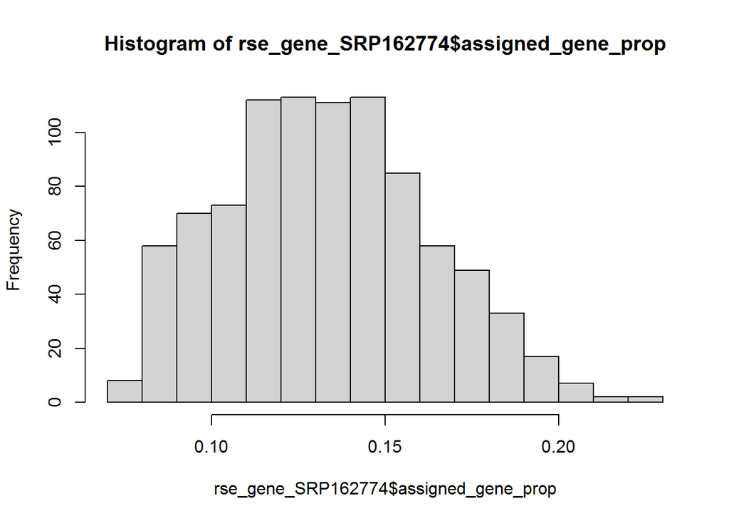

```r
rse_gene_SRP162774_unfiltered <- rse_gene_SRP162774
hist(rse_gene_SRP162774$assigned_gene_prop)
```

Veamos que pasa si quitamos las muestras abajo de 0.08.

```r
table(rse_gene_SRP162774$assigned_gene_prop < 0.08)
```

```
##
## FALSE  TRUE
##   903     8
```

```r
rse_gene_SRP162774 <- rse_gene_SRP162774[, rse_gene_SRP162774$assigned_gene_prop > 0.08]
gene_means <- rowMeans(assay(rse_gene_SRP162774, "counts"))
summary(gene_means)
```

```
##      Min.   1st Qu.    Median      Mean   3rd Qu.      Max.
##     0.000     0.000     0.028    12.544     1.559 18987.746
```

```r
rse_gene_SRP162774 <- rse_gene_SRP162774[gene_means > 0, ]
dim(rse_gene_SRP162774)
```

```
## [1] 44885   903
```

Al quitar estos genes nos quedan 44885 genes y 903 muestras, ahora veamoslos con boxplots.

```r
library("edgeR")
```

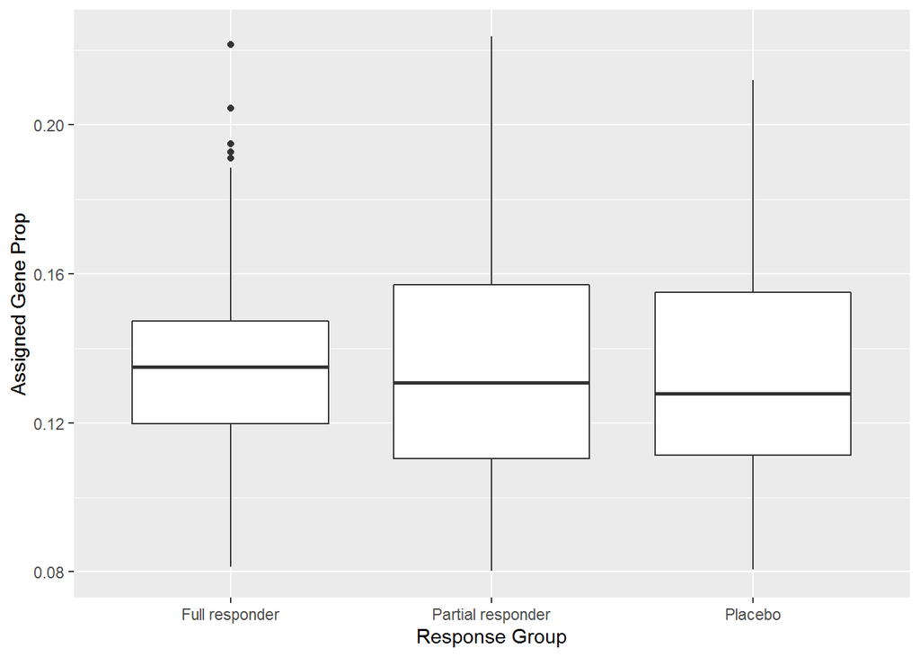

```r
library("ggplot2")
dge <- DGEList(
  counts = assay(rse_gene_SRP162774, "counts"),
  genes = rowData(rse_gene_SRP162774)
)
dge <- calcNormFactors(dge)
ggplot(as.data.frame(colData(rse_gene_SRP162774)), aes(y = assigned_gene_prop, x = sra_attribute.response_group)) +
  geom_boxplot() +
  ylab("Assigned Gene Prop") +
  xlab("Response Group")
```

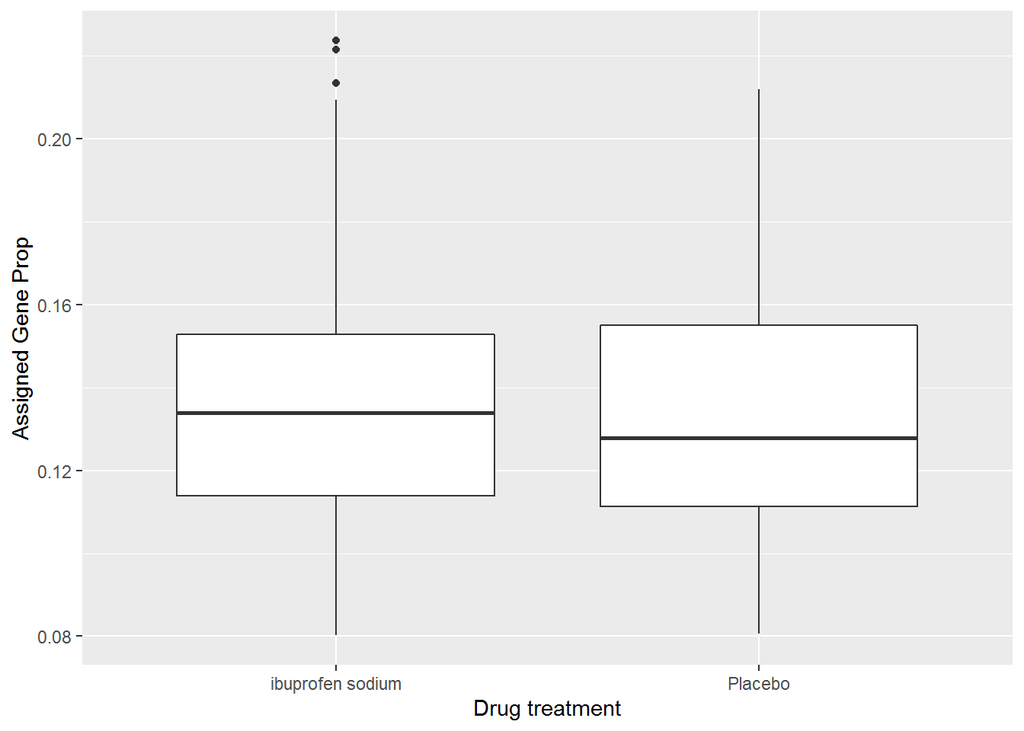

```r
ggplot(as.data.frame(colData(rse_gene_SRP162774)), aes(y = assigned_gene_prop, x = sra_attribute.drug_treatment)) +
  geom_boxplot() +
  ylab("Assigned Gene Prop") +
  xlab("Drug treatment")
```

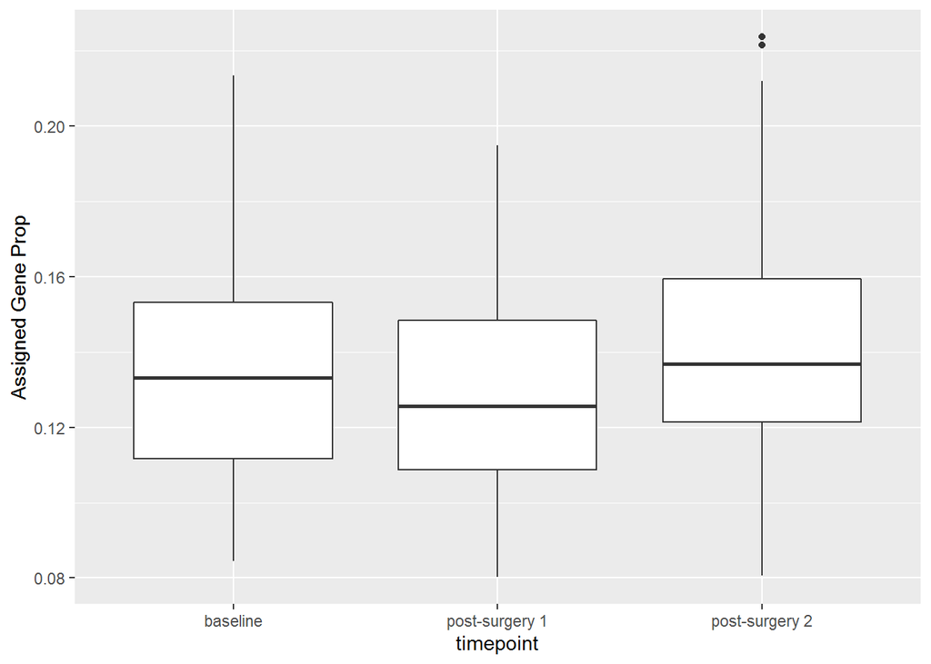

```r
ggplot(as.data.frame(colData(rse_gene_SRP162774)), aes(y = assigned_gene_prop, x = sra_attribute.timepoint)) +
  geom_boxplot() +
  ylab("Assigned Gene Prop") +
  xlab("timepoint")
```

En el caso de grupos de respuesta no hay mucha diferencia en la expresión de genes, pero se ve que los full responser tienen una concentración mayor cerca de su media, mientras que los partial responder tienen una mayor dispersión de sus datos casi igual al grupo control de placebo. En la gráfica de drug treatment tampoco se ve diferencia significativa. En la gráfica de timepoint el grupo de post-sugery 2 se ve con una ligera mayor expresión de genes que los otros dos.

```
## Coefficients not estimable: sra_attribute.drug_treatmentPlacebo
```

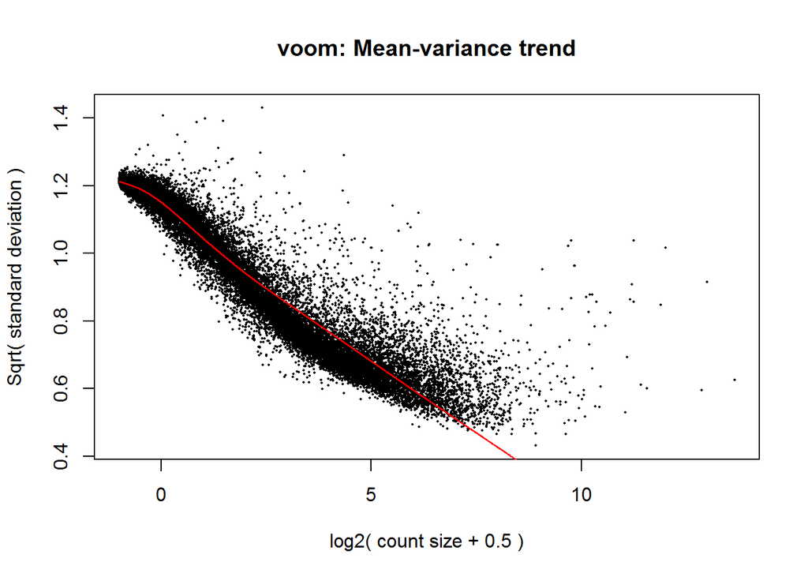

```r
library("limma")
mod <- model.matrix(~  sra_attribute.response_group + sra_attribute.drug_treatment + sra_attribute.timepoint + sra_attribute.gender + assigned_gene_prop,
                    data = colData(rse_gene_SRP162774))

vGene <- voom(dge, mod, plot = TRUE)
```

```r
eb_results <- eBayes(lmFit(vGene))
```

```
## Coefficients not estimable: sra_attribute.drug_treatmentPlacebo
```

```
## Warning: Partial NA coefficients for 44885 probe(s)
```

```
## Warning in .ebayes(fit = fit, proportion = proportion, stdev.coef.lim =
## stdev.coef.lim, : Estimation of var.prior failed - set to default value
```

```r
de_results <- topTable(
    eb_results,
    coef = 2,
    number = nrow(rse_gene_SRP162774),
    sort.by = "none"
)
```

¿nos da un warning de que el cálculo de coeficientes para drug_treatment da como resultado NA? ¿No pudo calcular por completo el modelo dado?

```r
library("pheatmap")
exprs_heatmap <- vGene$E[rank(de_results$adj.P.Val) <= 50, ]

## Creemos una tabla con información de las muestras
## y con nombres de columnas más amigables
df <- as.data.frame(colData(rse_gene_SRP162774)[, c("sra_attribute.response_group","sra_attribute.drug_treatment", "sra_attribute.timepoint", "sra_attribute.gender")])
colnames(df) <- c("Response","Treatment", "Timepoint", "Sex")

pdf("pheatmap_SRP162774.pdf", height = 14, useDingbats = FALSE)
pheatmap(
  exprs_heatmap,
  cluster_rows = TRUE,
  cluster_cols = TRUE,
  show_rownames = FALSE,
  show_colnames = FALSE,
  annotation_col = df
)
dev.off()
```